# Teaching Mathematics with Jupyter and PreText

### Virgil U Pierce, University of Northern Colorado

## What is Jupyter

*Jupyter* is primarily an interactive shell for Python with some additional functionality, mainly a *markdown* language syntax for cells that allows one to wrap Python code cells with descriptive text with some formating options.

*Markdown* is a What You See Is What You Get (WYSIWYG) language for typsetting similar to the language used by Wikipedia.

The most important feature is that it includes escape environments for typesetting mathematical expressions in $\LaTeX$ in line and as equations:

$$ \int x^2 dx = 2 x + C $$

- There are commands for bullets and numeration;
- **Bold**, *Italics*, and ~Strikeout~
- [html tags](https://virgilpierce.github.io/frontmatter-1.html)
- Section and subsection headings (see above)
- Importing images (using an HTML / XML type of syntax)

[figure not shown]

- You can also generate images using Python
- A quote environment (see below)

and probably some other options I have not discovered yet.

### What is Python?

From the Python Foundation's website:

> Python is an interpreted, object-oriented, high-level programming language with dynamic semantics.

As someone who is realitvely new to the language I can say that my experience has been:

- it is a powerful yet easy to learn language with far fewer things that need to be front loaded compared to C++ (no declarations),
- it is much easier to read Python code than other languages (in fact this is a primary focus of the design decisions),
- the interactive environment (like we are using in Jupyter) makes it behave like matlab (you can run a command and then see what happens),
- it is used extensively for computations in math and science,
- its plotting functions use the same syntax as matlab: plot( x, y, 'b-' )
- it is free and open (beer and liberty)

Downsides, as a programing language are the obvious

1. Because it is not a compiled language like C++ it is substantially slower,
2. Because it is more of a programing language than matlab, you may need to worry about the structure of variables and what they represent at some point.

I assert, and will try to show you here, that we can insulate students from the issues that occur with downside 2.

Downside 1 should not be an issue in most of the cases I have in mind for a class.

I have had students who have run into problems on their personal machines with computations taking too long in a data science class. I think the university Jupyter Hub I will use next time I teach that class will solve this problem.

As with all languages having everyone using the same set of package versions can be an issue. The Jupyter Hub should also address this.

### Why use a tool like Jupyter/Python in Teaching Mathematics

A major frustration in my teaching has been when I ask students to use a tool that I know is unrelated to what they would use in the 'real-world', in their careers, or in other classes.

- **Python has evolved to be a major tool used in STEM, from small minor tasks to major research projects**.
- **Jupyter/Python are common tools for Data Science and Mathematics in industry and were identified as important by emploers.**
- **Asking students to use and interact with Python outside of their programming class will improve their understanding of the language**
- **Asking students to use and interact with Python in more mathematics classes will expand their problem solving approaches.**

A goal at UNC is to have Python be included in courses throughout the Applied Mathematics degree to increase students fluency and ability to apply computational tools to a wide variety of mathematical and visualization problems.

### Using Jupyter/Python for Teaching Mathematics

#### Data Science with Pandas and Scikitlearn

Starting with the best example first.

- Pandas is a package for working with datasets.
- Scikitlearn is a package for modeling from data and developing predictions.

```python
ab = pd.read_csv('Abalone/abalone.csv', names = ['Sex', 'Length', 'Diameter', 'Height', 'Whole_weight', 'Sucked_weight', 'Viscera_weight', 'Shell_weight', 'Rings'])

ab.head()
```

|  | Sex | Length | Diameter | Height | Whole_weight | Sucked_weight | Viscera_weight | Shell_weight | Rings |
| --- | --- | --- | --- | --- | --- | --- | --- | --- | --- |
| 0 | M | 0.455 | 0.365 | 0.095 | 0.5140 | 0.2245 | 0.1010 | 0.150 | 15 |
| 1 | M | 0.350 | 0.265 | 0.090 | 0.2255 | 0.0995 | 0.0485 | 0.070 | 7 |
| 2 | F | 0.530 | 0.420 | 0.135 | 0.6770 | 0.2565 | 0.1415 | 0.210 | 9 |
| 3 | M | 0.440 | 0.365 | 0.125 | 0.5160 | 0.2155 | 0.1140 | 0.155 | 10 |
| 4 | I | 0.330 | 0.255 | 0.080 | 0.2050 | 0.0895 | 0.0395 | 0.055 | 7 |

```python
# Produce a numpy array with the Length variable and another with the Whole_Weight

X = np.atleast_2d(np.array([float(h) for h in ab.loc[:, 'Length']])).transpose()

y = np.array(ab.loc[:, 'Whole_weight'])
```

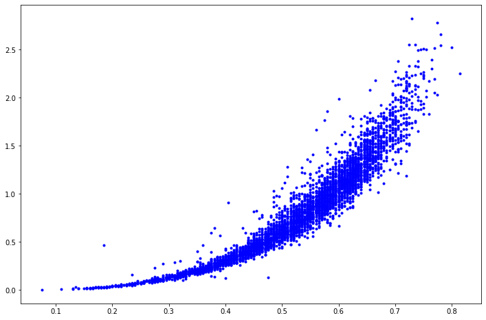

```python
plt.figure(figsize=(12, 8)) #adjust figure size
plt.plot(X, y, 'b.');
```

```python
X2 = np.atleast_2d(np.array([x**2 for x in X]))
X = np.concatenate([X, X2], axis=1)
print(X[:10])
```

```
[[0.455    0.207025]
 [0.35     0.1225  ]
 [0.53     0.2809  ]
 [0.44     0.1936  ]
 [0.33     0.1089  ]
 [0.425    0.180625]
 [0.53     0.2809  ]
 [0.545    0.297025]
 [0.475    0.225625]
 [0.55     0.3025  ]]
```

A side note here is that students in Linear Algebra that are heading towards a Data Science course will benifit from experience working with large non-square matrices. Typical problems either have many more samples than features, or in the case of images many more features than samples.

```python
from sklearn.linear_model import LinearRegression
reg = LinearRegression().fit(X, y)
c, b, a = reg.intercept_, *reg.coef_
c, b, a
```

```
(0.4449387447458826, -3.270155985954214, 7.257566596811781)
```

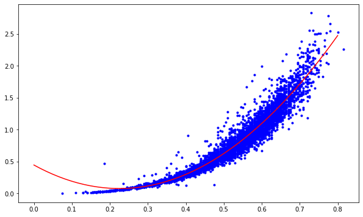

```python
# Plotting the resulting Quadratic Regression Model
plt.figure(figsize=(10,6))
plt.plot(X[:, 0], y, 'b.')
xx = np.linspace(0, 0.8, 50)
yy = a*xx**2 + b*xx + c
plt.plot(xx, yy, 'r-');
```

#### Linear Algebra

I have taught an introductory Linear Algebra using Matlab in the class a few times. My version of the course started as the Linear Algebra for Engineers at Ohio State designed by David Terman.

- The OSU course moved at what we would probably call a very fast pace
- The reason for the fast pace was that Eigenvalues and Eigenvectors were covered in much more detail including lots of applications, and so the course went very fast in order to have time for that.
- The course also included a discussion of errors and propogation of errors in solving linear systems.

The secret was that the course used Matlab for computations and students spent much of their time either translating application problems into LA problems or interpreting the results of computations done by the computer.

Compared to the courses I took in Linear Algebra, these focus much more on large and non-square problems.

```python
# matrices are numpy arrays
A = np.array( [ [1, 1, 2], [1, 1, 1], [2, 1, 1]])
print(A)
```

```
[[1 1 2]
 [1 1 1]
 [2 1 1]]
```

```python
v = np.array( [ [-1, 1, 3]]).transpose()
# As with matlab and mathematica it is annoyingly easy to enter row-vectors compared with column-vectors
print(v)
```

```
[[-1]
 [ 1]
 [ 3]]
```

```python
# students can multiply matrices using Python

print( A @ v )
```

```
[[6]
 [3]
 [2]]
```

Students (and you) will come face-to-face with the problem that exact results and numerical results are different things. In Python they use separate packages. See below on *Computational Linear Algebra*.

```python
# sympy Matrices can be made from numpy arrays. They include a nice display format.

AA = sy.Matrix( [[1, 1, 1, 2, -2, 4], [2, 2, 3, 1, -1, 5], [-1, -1, 1, 1/2, -1/2, 1]])
AA
```

$\displaystyle \left[\begin{matrix}1 & 1 & 1 & 2 & -2 & 4\\2 & 2 & 3 & 1 & -1 & 5\\-1 & -1 & 1 & 0.5 & -0.5 & 1\end{matrix}\right]$

```python
# We can compute the rref of a matrix

AA.rref()
```

```
(Matrix([
 [1, 1.0, 0, 0,    0, 0.529411764705882],
 [0,   0, 1, 0,    0, 0.882352941176471],
 [0,   0, 0, 1, -1.0,  1.29411764705882]]), (0, 2, 3))
```

Note that we get two items, the first is the rref, the second is a list of the columns with pivots.

```python
AA.rref()[0] # We can pull out the result by referencing the first item in the tuple.
```

$\displaystyle \left[\begin{matrix}1 & 1.0 & 0 & 0 & 0 & 0.529411764705882\\0 & 0 & 1 & 0 & 0 & 0.882352941176471\\0 & 0 & 0 & 1 & -1.0 & 1.29411764705882\end{matrix}\right]$

So early in the course, Python gives us a nice way for students to do the computations we are doing.

- I would have students using Elementary Matrices to encode row operations as we build up to RREF.
- Because they are using the computer for the computations we can use much larger problems than we would by hand
- With much larger problems, much more interesting things happen
- We are letting the computer do what it is good at - arithemetic, so students can do what they are best at - thinking.

Some notes on the logistics: I would code larger matrices as .csv files and then use Python tools to have students read them in.

Later I will discuss some tools I would use for providing Jupyter/Python examples to students, that are superior to the way I was using Matlab.

##### Computational Linear Algebra

The real power of these kinds of tools in a *Linear Algebra* class comes out when we get to eigenvalues and beyond (which in my classes would be a fair bit earlier than in a non-computer class).

The first method of computing eigenvalues that we typically introduce is as solutions of the polynomial equation

$$ \mbox{det}(A - \lambda I) = 0 $$

However some important points that we usually gloss over at this point in the course: General solutions to these polynomials are only guaranteed for an $A$ that is $n\times n$ with $n \leq 4$. Once $n$ is bigger than 4 solving this equation would be done using something like Newton's method which is slow compared to direct methods.

##### Eigenvalue Lesson

We first introduce students to Eigenvalues via experimentation with a Markov matrix

```python
M = np.array([0, 0, 0.5, 0, 0.5,
              0, 0, 1, 0, 0,
              0.25, 0.25, 0, 0.25, 0.25,
              0, 0, 0.5, 0, 0.5,
              0, 0, 0,   0, 1]).reshape(5,5).transpose()
print(M)
```

```
[[0.   0.   0.25 0.   0.  ]
 [0.   0.   0.25 0.   0.  ]
 [0.5  1.   0.   0.5  0.  ]
 [0.   0.   0.25 0.   0.  ]
 [0.5  0.   0.25 0.5  1.  ]]
```

Take a random vector $v$ and repeatedly apply $M$ (Markov matrices encode for instances how a population is moving between a set of cities at each time step).

```python
v = np.array([ [0.2, 0.2, 0.2, 0.2, 0.2]]).transpose()
print( M @ v)
```

```
[[0.05]
 [0.05]
 [0.4 ]
 [0.05]
 [0.45]]
```

```python
print( np.linalg.matrix_power(M, 2) @ v)
```

```
[[0.1]
 [0.1]
 [0.1]
 [0.1]
 [0.6]]
```

```python
v0 = np.linalg.matrix_power(M, 100) @ v  # Note the 100th power of a matrix, we would not compute by hand
                                  # without diagonalizing with eigenvalues/eigenvectors
print(v0)
```

```
[[1.77635684e-16]
 [1.77635684e-16]
 [1.77635684e-16]
 [1.77635684e-16]
 [1.00000000e+00]]
```

```python
print(M @ v0)

# and so students can find that 1 is an eigenvalue of M (up to machine zero).
```

```
[[4.44089210e-17]
 [4.44089210e-17]
 [3.55271368e-16]
 [4.44089210e-17]
 [1.00000000e+00]]
```

```python
# Verified with the numpy.linalg.eig function
print(np.linalg.eig(M)[0])
```

```
[ 1.00000000e+00 -7.07106781e-01 -4.20670443e-17  7.07106781e-01
  0.00000000e+00]
```

We can also play with companion matrices and see much larger examples.

```python
A = np.array( [ [0, 1, 0, 0, 0, 0],
               [0, 0, 1, 0, 0, 0],
               [0, 0, 0, 1, 0, 0],
               [0, 0, 0, 0, 1, 0],
               [0, 0, 0, 0, 0, 1],
               [192, -64, -156, 4, 25, 0]])
print(A)
```

```
[[   0    1    0    0    0    0]
 [   0    0    1    0    0    0]
 [   0    0    0    1    0    0]
 [   0    0    0    0    1    0]
 [   0    0    0    0    0    1]
 [ 192  -64 -156    4   25    0]]
```

```python
out = np.linalg.eig(A)
print(out[0].round(5))
# .round() is used in the output because the tolerances for numpy.linalg.eig() are producing results
# that have an error of order 10^-6.

# Symmetric matrices have better algorithms implemented that will give more accurate results.
```

```
[-4.+0.j  4.+0.j  3.+0.j -2.+0.j -2.-0.j  1.+0.j]
```

```python
# We can use the symbolic tools to verify this result

x = sy.symbols('x')
sy.expand((x+4)*(x-4)*(x-3)*(x+2)*(x+2)*(x-1))
```

$\displaystyle x^{6} - 25 x^{4} - 4 x^{3} + 156 x^{2} + 64 x - 192$

##### Other Examples for Linear Algebra to Consider

Other nice and large non-square examples that Jupyter/Python is well equiped to work with include:

- Linear Regression as the solution of a large non-square linear system of equations resulting from a Calculus optimization;
- Linear Regression as an orthogonal projection;
- For that matter orthogonal projection more generally.

#### Calculus

Unfortunately, given the short time, and also that I do not have examples already prepared, I will not give details of how I would use this in a Calculus course. Instead just some ideas:

- I think the best use of technology in a Calculus class is creating visualizations
- Although there is a sympy package for doing symbolic computations
- Mostly what I would suggest is creating Jupyter worksheets for students to use, and making use of the cell lock feature I will discuss here.

##### Cell Lock

I was introduced to the cell lock feature at the Banff workshop "Open Education Resources and Technologies in Mathematics." Patrick Walls (UBC) was demonstrating the *NBGrader* package: a tool for automatically grading student Jupyter submissions when we noticed a feature available to Jupyter Notebooks.

To explain, a Jupyter Notebook is a set of data in a format called JSON. Each cell in the notebook is represented as a JSON Object (a collection of unordered data) including the text of the cell and the type of cell it is (Markdown or Code). However there are additional fields that Jupyter can interpret and one called "editable" can be set to false.

The following cells would be the "worksheet" for students to use to produce the graph of a function and their derivative of it.

There are three editable cells. The function definition, its derivative, and a cell giving the domain for the graph. Then the rest of the worksheet is executable but not editable.

```python
# Enter the function you are graphing after "return"
# Note that powers which we Latex with ^ are represented in Python by **

def f(x):
    return x**2 + 2*x + 1
```

```python
# Enter the derivative of the function you are graphing after "return"

def df(x):
    return 2*x + 2
```

```python
# Here you can adjust the domain for the graph below

xmin, xmax = -7, 5
```

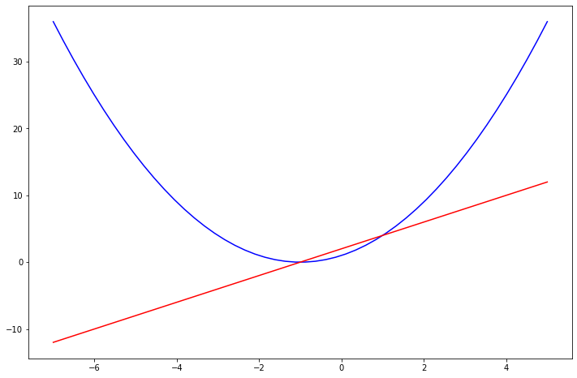

```python
# Execute this cell to graph the function and its derivative
plt.figure(figsize=(12,8))
xx = np.linspace(xmin, xmax, 50)
plt.plot(xx, f(xx), 'b-')
plt.plot(xx, df(xx), 'r-');
```

#### Additional Tools: Jupyter Hub

As I have been thinking about the goal of exposing students to Jupyter/Python more frequently by including it in their mathematics class an issue arose that need to be solved:

- While at UNC 99% of students report having a personal device:
  - That device is often a tablet
  - If it is a computer it is often the cheapest computer sold by a retailer.
  - You can expect a class to have mixture of macs and PCs, and in many cases a Linux machine or two.

These devices are slow, and keeping all of the versions of Jupyter, Python, and the packages used the same is impossible. Some commands are operating system dependent, particularly ones that interface with the file system.

These issues can be addressed by using a JupyterHub. A JupyterHub essentially serves up the Jupyter/Python environment on an external server rather than having students run it on their local machine.

- A simple hub can be set up on a cloud server for not too much (a few dollars per day which you can also turn off when it is not being used),
- A more involved hub can be set up by your IT,
- Students will have a uniform environment for using Jupyter/Python: Your worksheets will work out of the box, and they will be able to share worksheets with you and other students,
- Because it runs on the server it can be used on a Tablet or Phone.

## Sharing Jupyter Notebooks

I share my Jupyter notebooks, both the class notes and the worksheets we use in two ways.

- The entire set of notebooks including alternate versions, as well as notebooks by other authors I want to share are maintained on a Github for the class. Students receive in the syllabus the link for downloading (or cloning) the git.
- The final versions of the notebooks are converted to PreText and then published as sections /chapters of the course textbook.

Students make use of both methods of obtaining the notebooks. It would be worth doing some research into why they are choosing one method or the other.

I think many of them using the PreText like the navigation tools attached that allow them to skip around. I also added some hyperlinks between sections, definitions, etc.

### Why convert Jupyter to PreText

So the premise then is: We have a class that is using Python as a computational tool to some extent, the worksheets or notes are being prepared using Jupyter. We would like to convert them to PreText to publish as a textbook. Why? (my thoughts)

1. The Textbook becomes a somewhat more fixed version of the notes,
2. Some students prefer to access the course materials via the PreText book,
3. We might want to add PreText features (links, index, etc.) or
4. We are including the notebooks as part of a larger PreText project.

The downside, if you have not noticed already, is that you need to add an extension for spell checking Jupyter markdown cells.

#### Compiling Notebooks to a PreText Book

The conversion script is available from: https://github.com/virgilpierce/jpconvert

Some notes about how it works:

1. Jupyter notebooks, as we've discussed are JSON files with each cell recorded as an object.
2. Accordingly the conversion script scans the notebooks cell-by-cell
3. It uses the JSON tags to identify Markdown or Code and then sets the Code into PreText Code Blocks
4. While Jupyter's Markdown contains Sectioning commands they do not *close* thus the converter needs to make some assumptions about when sections and other blocks close.
5. Jupyter's Markdown is simple in some other ways (for instance the enumerate and itemize blocks are identified with just a leading number or -).

##### Left to be done

Some things that are not yet done by the converter that need to be fixed:

- It should identify at the begining what the top level section is (i.e. Book or Article).
- The Jupyter Notebook JSON contains the actuall PNG data for the Python generated images. However I have not been able to have the script save that as a PNG file and add the image code to the PreText.